# Midway Evalutation

Leon Eyrich Jessen

2026

## Midway Evaluation

- Our opportunity to understand if the course elements works as intended
- Your opportunity to let us know, how the course looks on the students side
- Super important to align
- 67 out of 140 enrolled students answered this year
- THANK YOU for this important contribution!

## Highlights: What’s Working Well in the Course

- Hands-on exercises and practical sessions are consistently praised as engaging, well-designed, and central to learning success.
- Instructor and TA support receive strong positive mentions—students find the guidance clear, helpful, and motivating.
- Collaborative learning through group work is viewed as effective for understanding material and maintaining engagement.

## Highlights: What could be better

- Clarify course scope and reading expectations — several students mention uncertainty about what constitutes the official curriculum (“pensum”) and desired preparation depth.
- Balance assignment workload and pacing — a few respondents note that some exercises or lab assignments feel time-intensive or unevenly distributed.
- Enhance lecture–exercise integration — while lectures are appreciated, students suggest even tighter linkage between theory and practical sessions.

## Highlights: Group Assignment Element

- Group feedback is highly valued — students frequently describe it as useful, constructive, and motivating for improving their work.
- Collaborative dynamics are generally positive, with many appreciating how group work reinforces understanding and accountability.
- Some variation in group engagement — while most experiences are good, a few mention uneven contribution or occasional coordination challenges.

## Highlights: Open input and feedback

- Strong overall satisfaction — many spontaneous comments describe the course as fun, well-structured, and one of the best of the semester.
- Appreciation for clarity and organization — students commend the teaching structure, the GitHub materials, and the logical flow of exercises and lectures.
- Constructive suggestions — a few note a desire for more real-world data examples and slightly extended exercise time to consolidate learning.

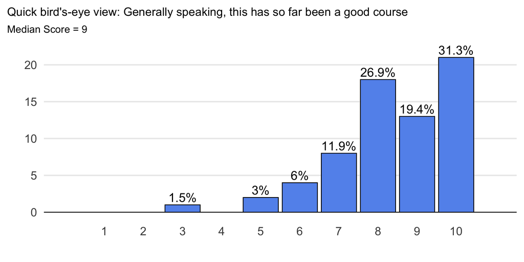

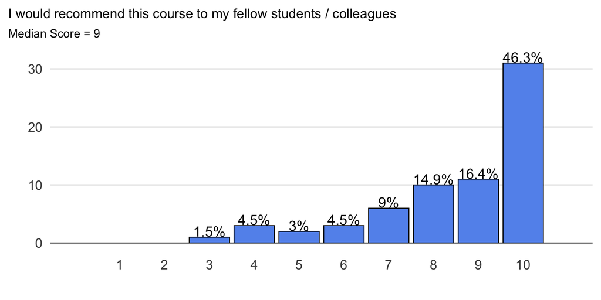

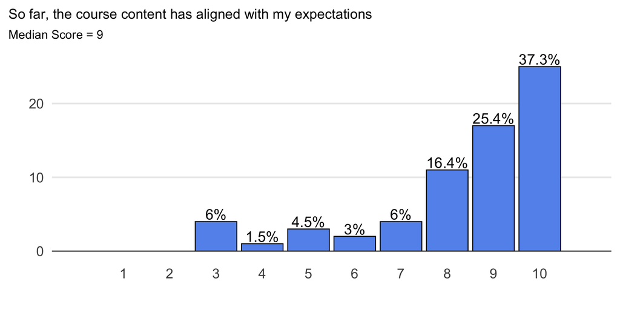

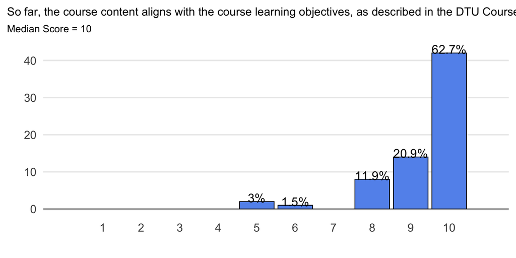

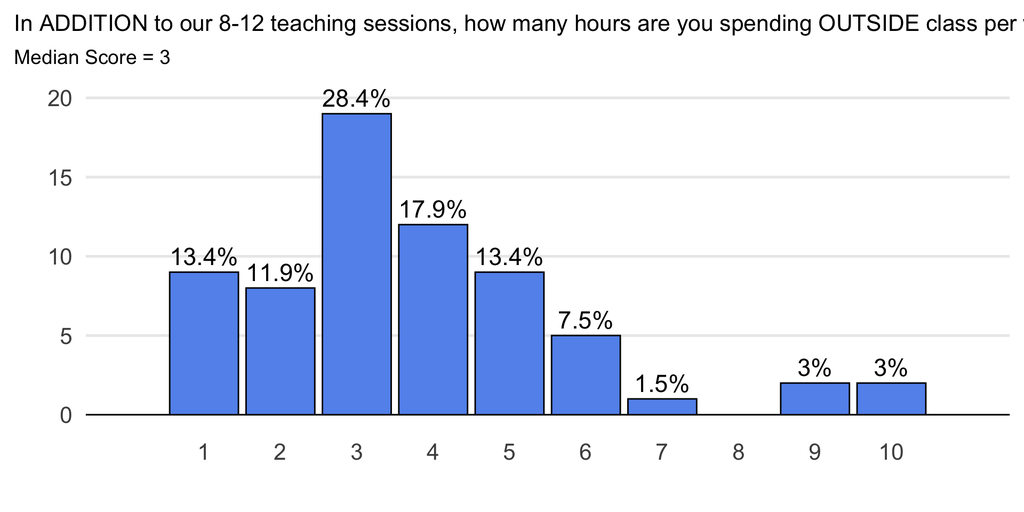

*Average: 4 + 3.7 +/- 2.1 ~ 6-10h/week, expected time usage for 5 ECTS ~9-10h/week*